# Milestone 1 Report

Tal Noznisky

6/26/2018

# Corpus Evaluation and N-Gram First Pass

This document summarizes my first step into development of natural language prediction tool. We will evaluate the size and composition of an English language corpus culled from internet resources. From there, we’ll parse the text into n-grams and hypothesize the next steps toward building a predictive algorithm from those n-grams.

## Understandthing the files

We are going to aggregate three files containing vernacular English from Twitter, blogs, and news sources. Ingesting the files was a significant hurdle, in learning, time, and my laptop’s poorly managed disk space. Due to the overwhelming capacity required, this stage will be useful for determining the proper ratios for partitioning training and testing data sets further along in this project.

```r
#file size
rows <- c("blogs", "news", "twitter")
size <- function(file){
  info <- file.info(file)
  return(info$size)
}
sizes <- data.frame(sapply(files, size))
#count lines
linecount <- data.frame(sapply(files, countLines))
#count words
word_count <- function(file){
  con <- file(file, "r", blocking=FALSE)
  x <- readLines(con)
  return(wordcount(x, sep=" ", count.function=sum))
}
wordcount <- data.frame(sapply(files, word_count))
rownames(sizes) <- rows
rownames(linecount) <- rows
rownames(wordcount) <- rows
print(sizes)
```

```
##         sapply.files..size.
## blogs             210160014
## news              205811889
## twitter           167105338
```

```r
print(linecount)
```

```
##         sapply.files..countLines.
## blogs                      899288
## news                      1010242
## twitter                   2360148
```

```r
print(wordcount)
```

```
##         sapply.files..word_count.
## blogs                    37334131
## news                     34372530
## twitter                  30373543
```

## Aggregate the data

With the data measured out now, we’ll aggregate a fraction of it for demonstrative purposes, and to begin parsing the n-grams into the model we need. In the meantime, we are using only 1% of the total corpus as a sample. This small sample is not meant to provide a substantial model of the data set, but to provide insight into its distribute as well as a lightweight intitiation to n-gram modeling.

```r
datalist = list()
for (file in files){
  con <- file(file,"r")
  nlines <- countLines(file)
  lines <- readLines(con,nlines*.01)
  datalist[[file]] <- lines
  rm(lines)
}
sample = tolower(do.call(concatenate, datalist))
rm(datalist)
```

```r
ng.1.df <- data.frame(get.phrasetable(ngram(sample, n = 1)))
ng.2.df <- data.frame(get.phrasetable(ngram(sample, n = 2)))
ng.3.df <- data.frame(get.phrasetable(ngram(sample, n = 3)))
head(ng.1.df)
```

```
##   ngrams  freq       prop
## 1   the  46650 0.04576922
## 2    to  26982 0.02647256
## 3   and  23563 0.02311811
## 4     a  23546 0.02310144
## 5    of  19904 0.01952820
## 6     i  15862 0.01556251
```

```r
head(ng.2.df)
```

```
##     ngrams freq        prop
## 1  of the  4188 0.004108932
## 2  in the  4021 0.003945085
## 3  to the  2117 0.002077032
## 4 for the  2020 0.001981863
## 5  on the  1890 0.001854317
## 6   to be  1572 0.001542321
```

```r
head(ng.3.df)
```

```
##            ngrams freq         prop
## 1     one of the   329 0.0003227889
## 2       a lot of   298 0.0002923741
## 3 thanks for the   241 0.0002364502
## 4        to be a   174 0.0001707151
## 5    going to be   169 0.0001658095
## 6      i want to   151 0.0001481493
```

## Assess n-gram distribution

Now that the n-grams are structured into data frames we can take a look at their shape. That will help us understand the distribution of the n-gram dictionary. Although langauge coverage is not yet established in this report, we’ll see below that the data is strongly skewed to the right, and to very low counts. This gives the data a very long tail for n-gram tables from n=1 to n=3.

```r
skewness(ng.1.df$freq)
```

```
## [1] 116.1665
```

```r
skewness(ng.2.df$freq)
```

```
## [1] 156.6244
```

```r
skewness(ng.3.df$freq)
```

```
## [1] 66.27794
```

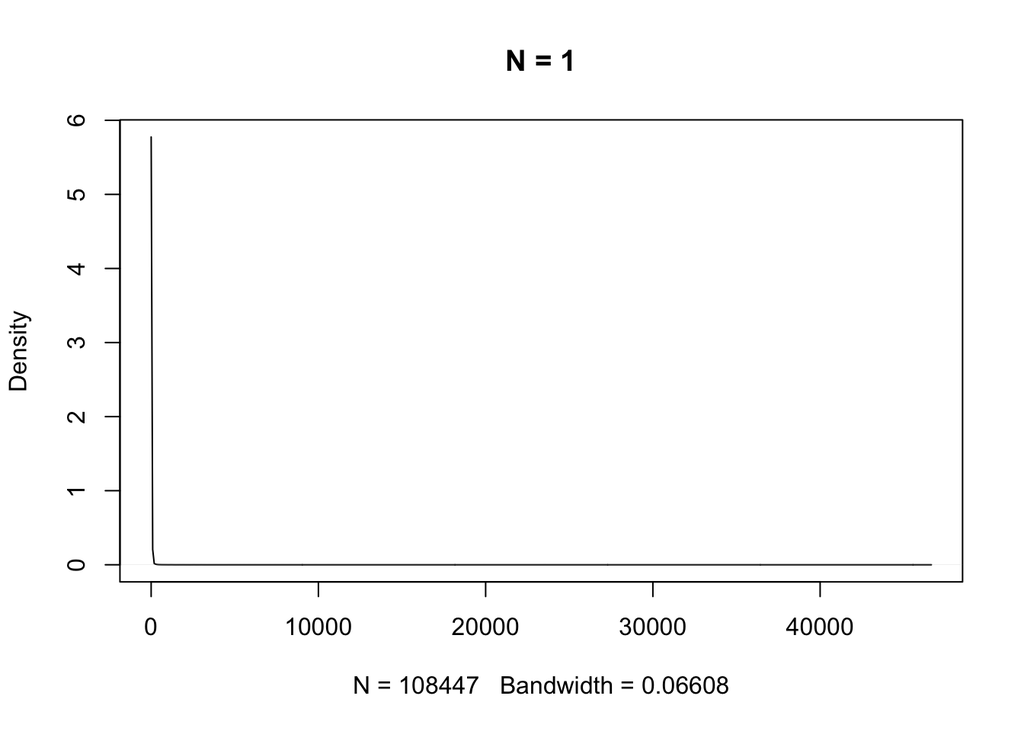

```r
plot(density(ng.1.df$freq), main="N = 1")
```

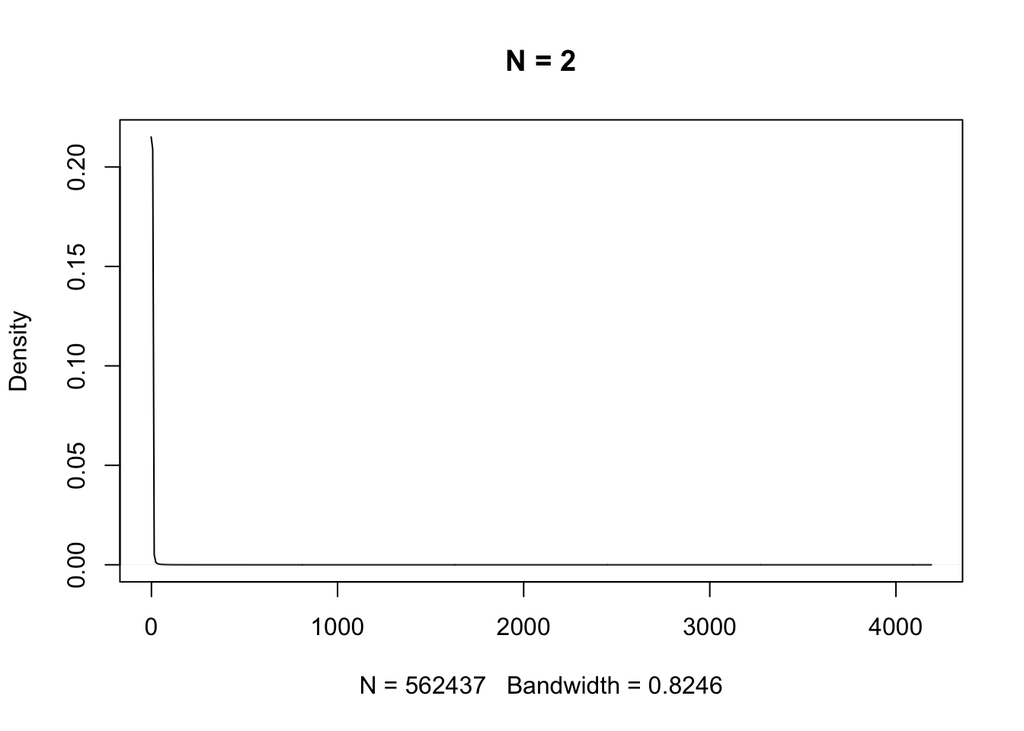

```r
plot(density(ng.2.df$freq), main="N = 2")
```

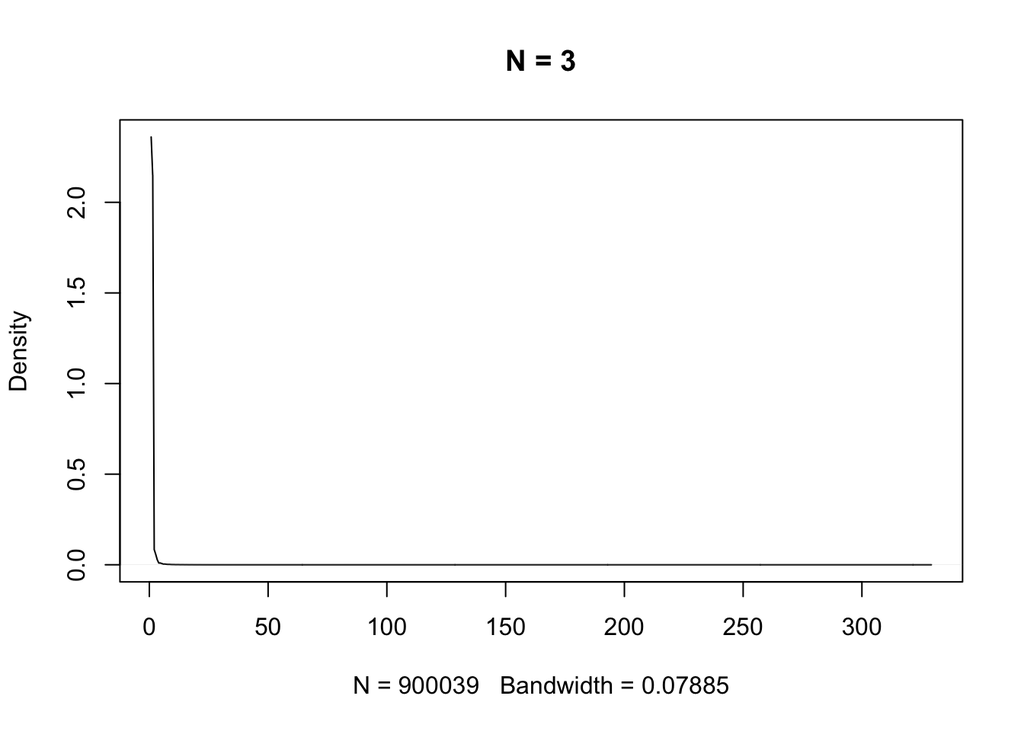

```r
plot(density(ng.3.df$freq), main="N = 3")
```

## Summary and next steps

Thus we have a sense of size and shape of the data. Plus the data is fairly well formatted for both further analysis and modeling. The essential tasks for the next steps are: 1. Determine how to store and recall the n-gram probabilities efficiently for the predictive modek. 2. How to handle n-grams that aren’t included in the training data set. 3. Evaluate the model’s effectiveness and accuracy.